# 33_ntwrk_incidence_mat

## 33_ntwrk_incidence_mat

#### Question

1. A matrix can be used to represent incidence relationships in a network. As a simple example, the [directed graph](https://en.wikipedia.org/wiki/Directed_graph) below

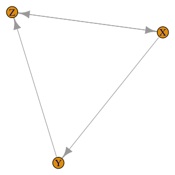

   can be represented with the following matrix

   $$\left[
   \begin{matrix}
   0 & 1 & 1\\
   0 & 0 & 1\\
   1 & 0 & 0\\
   \end{matrix}
   \right]$$

   because
   - $X$ points to $Y$
   - $X$ points to $Z$
   - $Y$ points to $Z$
   - $Z$ points to $X$

   Notice I did assume the rows and columns follow alphabetical order.

## Write matrix from directed graph

   Here is another directed graph:

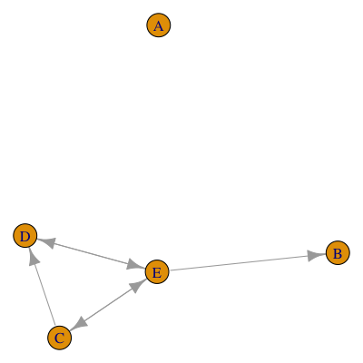

   Please write the corresponding matrix. Assume rows and columns represent $a$ through $e$ in alphabetical order. Putting a 1 in the matrix represents the letter of that row points toward the letter of the column.

#### Question

2. A matrix can be used to represent incidence relationships in a network. As a simple example, the [directed graph](https://en.wikipedia.org/wiki/Directed_graph) below

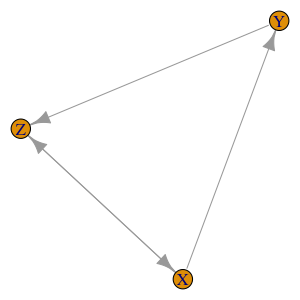

   can be represented with the following matrix

   $$\left[
   \begin{matrix}
   0 & 1 & 1\\
   0 & 0 & 1\\
   1 & 0 & 0\\
   \end{matrix}
   \right]$$

   because
   - $X$ points to $Y$
   - $X$ points to $Z$
   - $Y$ points to $Z$
   - $Z$ points to $X$

   Notice I did assume the rows and columns follow alphabetical order.

## Write matrix from directed graph

   Here is another directed graph:

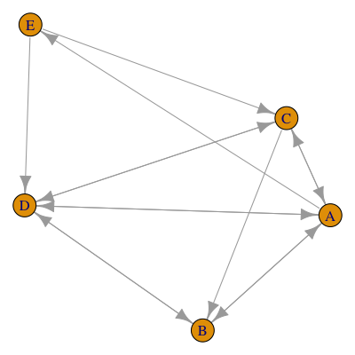

   Please write the corresponding matrix. Assume rows and columns represent $a$ through $e$ in alphabetical order. Putting a 1 in the matrix represents the letter of that row points toward the letter of the column.

#### Question

3. A matrix can be used to represent incidence relationships in a network. As a simple example, the [directed graph](https://en.wikipedia.org/wiki/Directed_graph) below

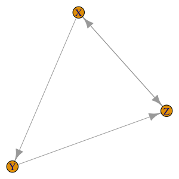

   can be represented with the following matrix

   $$\left[
   \begin{matrix}
   0 & 1 & 1\\
   0 & 0 & 1\\
   1 & 0 & 0\\
   \end{matrix}
   \right]$$

   because
   - $X$ points to $Y$
   - $X$ points to $Z$
   - $Y$ points to $Z$
   - $Z$ points to $X$

   Notice I did assume the rows and columns follow alphabetical order.

## Write matrix from directed graph

   Here is another directed graph:

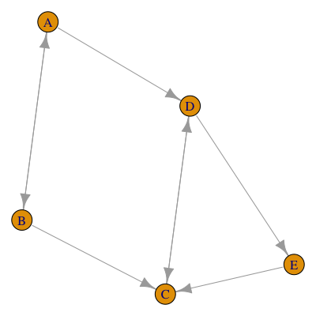

   Please write the corresponding matrix. Assume rows and columns represent $a$ through $e$ in alphabetical order. Putting a 1 in the matrix represents the letter of that row points toward the letter of the column.

#### Question

4. A matrix can be used to represent incidence relationships in a network. As a simple example, the [directed graph](https://en.wikipedia.org/wiki/Directed_graph) below

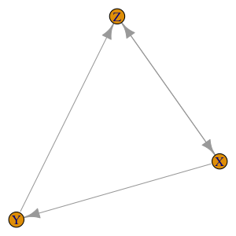

   can be represented with the following matrix

   $$\left[
   \begin{matrix}
   0 & 1 & 1\\
   0 & 0 & 1\\
   1 & 0 & 0\\
   \end{matrix}
   \right]$$

   because
   - $X$ points to $Y$
   - $X$ points to $Z$
   - $Y$ points to $Z$
   - $Z$ points to $X$

   Notice I did assume the rows and columns follow alphabetical order.

## Write matrix from directed graph

   Here is another directed graph:

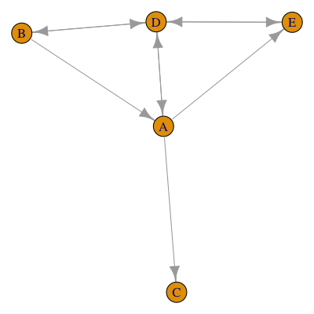

   Please write the corresponding matrix. Assume rows and columns represent $a$ through $e$ in alphabetical order. Putting a 1 in the matrix represents the letter of that row points toward the letter of the column.

#### Question

5. A matrix can be used to represent incidence relationships in a network. As a simple example, the [directed graph](https://en.wikipedia.org/wiki/Directed_graph) below

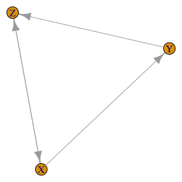

   can be represented with the following matrix

   $$\left[
   \begin{matrix}
   0 & 1 & 1\\
   0 & 0 & 1\\
   1 & 0 & 0\\
   \end{matrix}
   \right]$$

   because
   - $X$ points to $Y$
   - $X$ points to $Z$
   - $Y$ points to $Z$
   - $Z$ points to $X$

   Notice I did assume the rows and columns follow alphabetical order.

## Write matrix from directed graph

   Here is another directed graph:

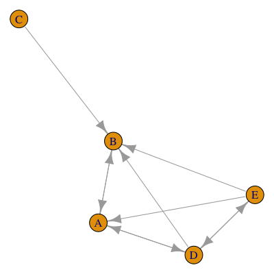

   Please write the corresponding matrix. Assume rows and columns represent $a$ through $e$ in alphabetical order. Putting a 1 in the matrix represents the letter of that row points toward the letter of the column.

#### Question

6. A matrix can be used to represent incidence relationships in a network. As a simple example, the [directed graph](https://en.wikipedia.org/wiki/Directed_graph) below

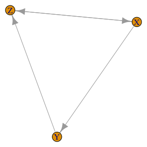

   can be represented with the following matrix

   $$\left[
   \begin{matrix}
   0 & 1 & 1\\
   0 & 0 & 1\\
   1 & 0 & 0\\
   \end{matrix}
   \right]$$

   because
   - $X$ points to $Y$
   - $X$ points to $Z$
   - $Y$ points to $Z$
   - $Z$ points to $X$

   Notice I did assume the rows and columns follow alphabetical order.

## Write matrix from directed graph

   Here is another directed graph:

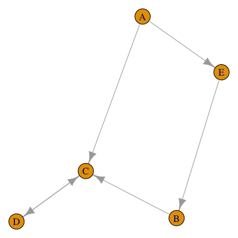

   Please write the corresponding matrix. Assume rows and columns represent $a$ through $e$ in alphabetical order. Putting a 1 in the matrix represents the letter of that row points toward the letter of the column.

#### Question

7. A matrix can be used to represent incidence relationships in a network. As a simple example, the [directed graph](https://en.wikipedia.org/wiki/Directed_graph) below

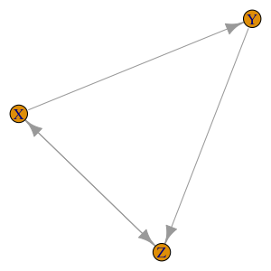

   can be represented with the following matrix

   $$\left[
   \begin{matrix}
   0 & 1 & 1\\
   0 & 0 & 1\\
   1 & 0 & 0\\
   \end{matrix}
   \right]$$

   because
   - $X$ points to $Y$
   - $X$ points to $Z$
   - $Y$ points to $Z$
   - $Z$ points to $X$

   Notice I did assume the rows and columns follow alphabetical order.

## Write matrix from directed graph

   Here is another directed graph:

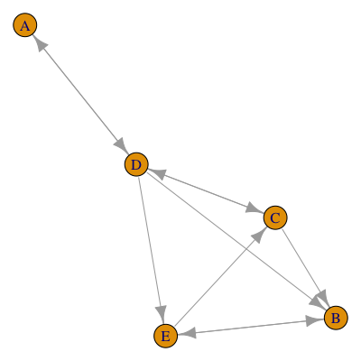

   Please write the corresponding matrix. Assume rows and columns represent $a$ through $e$ in alphabetical order. Putting a 1 in the matrix represents the letter of that row points toward the letter of the column.

#### Question

8. A matrix can be used to represent incidence relationships in a network. As a simple example, the [directed graph](https://en.wikipedia.org/wiki/Directed_graph) below

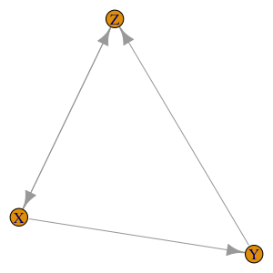

   can be represented with the following matrix

   $$\left[
   \begin{matrix}
   0 & 1 & 1\\
   0 & 0 & 1\\
   1 & 0 & 0\\
   \end{matrix}
   \right]$$

   because
   - $X$ points to $Y$
   - $X$ points to $Z$
   - $Y$ points to $Z$
   - $Z$ points to $X$

   Notice I did assume the rows and columns follow alphabetical order.

## Write matrix from directed graph

   Here is another directed graph:

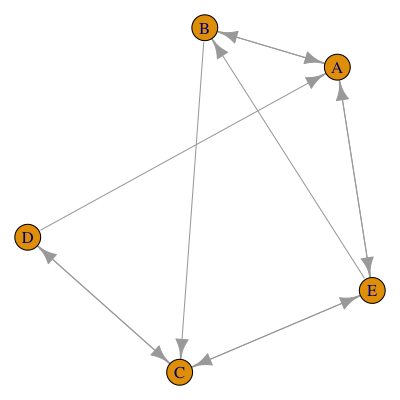

   Please write the corresponding matrix. Assume rows and columns represent $a$ through $e$ in alphabetical order. Putting a 1 in the matrix represents the letter of that row points toward the letter of the column.